# China Real Estate Demand Prediction

**Final Project – Statistical Learning (OLS, Ridge, LASSO, kNN)**  
Shuang Li | Illinois Institute of Technology | 2025

# Final Project: Model Selection and Evaluation in Statistical Learning

### China Real Estate Demand Prediction

This notebook serves as the formal academic report for the *Final Project* in the MATH 569 Statistical Learning course.  
It demonstrates the complete process of applying fundamental statistical learning techniques to a real-world dataset.

**Objective:**  
To predict the *monthly transaction amount of new houses* in various Chinese urban sectors by applying multiple statistical learning models, evaluating their performance rigorously, and identifying the most suitable model for this problem.

**Key Steps:**

1. Environment Setup and Package Installation
2. Data Understanding and Preprocessing
3. Exploratory Data Analysis (EDA)
4. Feature Engineering (Leakage-Safe Lags)
5. Chronological Train / Validation / Test Split
6. Model Rationale, Leakage Prevention, and Validation-Based Selection
7. Final Evaluation and Interpretation
8. Conclusions and Discussion

All reasoning, assumptions, and methodological choices are explained throughout.

```python
# ==========================================================
# 1. ENVIRONMENT SETUP
# ==========================================================
# This cell ensures all dependencies are installed correctly even on a fresh system.

%pip install --quiet --upgrade pip
%pip install --quiet pandas numpy matplotlib scikit-learn seaborn jupyterlab notebook

import os, re, math, numpy as np, pandas as pd, matplotlib.pyplot as plt, seaborn as sns
from sklearn.model_selection import GridSearchCV
from sklearn.linear_model import LinearRegression, Ridge, Lasso
from sklearn.metrics import mean_squared_error, mean_absolute_error, r2_score
from sklearn.preprocessing import StandardScaler
from sklearn.neighbors import KNeighborsRegressor

pd.set_option("display.max_columns", 120)
sns.set_style("whitegrid")

# Project directory (edit if different)
DATA_DIR = "./train"
OUT_MERGED = "./merged_train.csv"
TARGET = "amount_new_house_transaction"
TIME_COL = "month"
SECTOR_COL = "sector"
RANDOM_STATE = 42

print("Environment successfully prepared.")
```

```
Environment successfully prepared.
```

## Dataset Selection and Description

The dataset originates from the **China Real Estate Demand Prediction** competition (Kaggle, 2024), repurposed here for educational use.  
It is well-suited for this project because it features:

- A mix of numeric and categorical variables,
- Temporal and spatial components,
- A continuous target suitable for regression,
- Socio-economic realism consistent with applied statistical learning.

**Predictive Target:**  
`amount_new_house_transaction` — total monetary value (×10,000 yuan) of monthly new-house transactions by sector.

**Supporting Predictors:**

- Housing transactions (new and pre-owned),
- Land transactions,
- Nearby-sector metrics,
- Sector-level points-of-interest (population, infrastructure, education, etc.).

The dataset’s temporal span enables realistic forecasting and emphasizes the importance of time-order preservation to avoid data leakage.

## 2 Data Understanding and Merging

This section describes and merges the multiple CSV files comprising the training data.  
The dataset is divided into several domain-specific tables:

| File | Description |
| --- | --- |
| `new_house_transactions.csv` | Core table — monthly new-house transaction statistics (target variable included). |
| `*_nearby_sectors.csv` | Aggregated indicators of neighboring areas (to capture spatial effects). |
| `pre_owned_house_transactions.csv` | Market activity for pre-owned homes. |
| `land_transactions.csv` | Land-sale metrics influencing housing supply. |
| `sector_POI.csv` | Static geographic and demographic information for each sector. |

These tables share common keys:

- `month` (temporal identifier), and
- `sector` (spatial identifier).

They are merged on these two keys to form one comprehensive analytical dataset.  
All non-existent sector-month combinations imply *zero* transaction activity, consistent with the competition instructions.

```python
# ==========================================================
# 2. LOAD AND MERGE TRAINING DATA
# ==========================================================

RAW_FILES = {
    "new": "new_house_transactions.csv",
    "new_near": "new_house_transactions_nearby_sectors.csv",
    "pre": "pre_owned_house_transactions.csv",
    "pre_near": "pre_owned_house_transactions_nearby_sectors.csv",
    "land": "land_transactions.csv",
    "land_near": "land_transactions_nearby_sectors.csv",
    "poi": "sector_POI.csv",
}

def parse_month_col(df, col="month"):
    """Convert mixed Chinese/English month formats into datetime (YYYY-MM)."""
    if col not in df.columns:
        return df
    df[col] = df[col].astype(str).str.replace(r"_sector\s*\d+$", "", regex=True).str.strip()
    parsed = pd.to_datetime(df[col], errors="coerce")
    mask = parsed.isna() & df[col].str.contains("年", na=False)
    if mask.any():
        def cn_parse(s):
            m = re.match(r"^(\d{4})年(\d{1,2})月", str(s))
            if m:
                return pd.Timestamp(year=int(m.group(1)), month=int(m.group(2)), day=1)
            return pd.NaT
        parsed.loc[mask] = df.loc[mask, col].apply(cn_parse)
    df[col] = parsed.dt.to_period("M").dt.to_timestamp()
    return df

def load_csv(path):
    df = pd.read_csv(path)
    if "month" in df.columns:
        df = parse_month_col(df, "month")
    scols = [c for c in df.columns if c.lower().startswith("sector")]
    if "sector" not in df.columns and scols:
        df = df.rename(columns={scols[0]: "sector"})
    return df

# Load all train tables
dfs = {}
for key, fname in RAW_FILES.items():
    path = os.path.join(DATA_DIR, fname)
    if os.path.exists(path):
        dfs[key] = load_csv(path)
    else:
        print("Missing file:", fname)

# Merge sequentially
base = dfs["new"].copy()
for k in ["new_near", "pre", "pre_near", "land", "land_near"]:
    if k in dfs:
        right = dfs[k].copy()
        dup_cols = [c for c in right.columns if c in base.columns and c not in [TIME_COL, SECTOR_COL]]
        if dup_cols:
            right = right.drop(columns=dup_cols)
        base = base.merge(right, on=[TIME_COL, SECTOR_COL], how="outer")

# Merge static POI info
if "poi" in dfs:
    poi = dfs["poi"].drop_duplicates(subset=[SECTOR_COL])
    dup_cols = [c for c in poi.columns if c in base.columns and c != SECTOR_COL]
    if dup_cols:
        poi = poi.drop(columns=dup_cols)
    base = base.merge(poi, on=SECTOR_COL, how="left")

# Ensure target column exists
if TARGET not in base.columns:
    cand = [c for c in base.columns if "amount_new_house_transaction" in c]
    base[TARGET] = base[cand[0]] if cand else 0.0

base[TARGET] = base[TARGET].fillna(0)
base = base.sort_values([TIME_COL, SECTOR_COL]).reset_index(drop=True)
print("Merged dataset shape:", base.shape)

# Save intermediate file for reproducibility
base.to_csv(OUT_MERGED, index=False)
```

```
Merged dataset shape: (6432, 178)
```

## 3 Exploratory Data Analysis (EDA)

The purpose of this section is to gain a descriptive understanding of the merged dataset before applying any modeling techniques.  
According to the Statistical Learning syllabus (Module 1: *Terminology and Ideas*), exploratory analysis is a prerequisite to formal modeling because it allows one to:

1. Visualize the distribution and scale of the response variable.
2. Detect outliers and assess the need for transformation.
3. Identify missing-value patterns.
4. Examine temporal trends and inter-feature relationships.
5. Develop hypotheses about linearity and variance structure that guide model choice.

The EDA here emphasizes temporal patterns and the approximate linear relationships among transaction-related variables, consistent with the linear modeling framework taught in the course.

```
Observations: 6,432
Features: 178
Date range: 2019-01-01 → 2024-07-01
Unique sectors: 96

Columns with >20% missing:
num_land_transactions_nearby_sectors    0.21875
construction_area_nearby_sectors        0.21875
planned_building_area_nearby_sectors    0.21875
transaction_amount_nearby_sectors       0.21875
dtype: float64
```

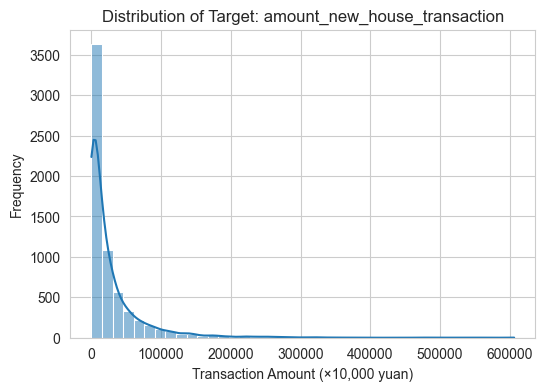

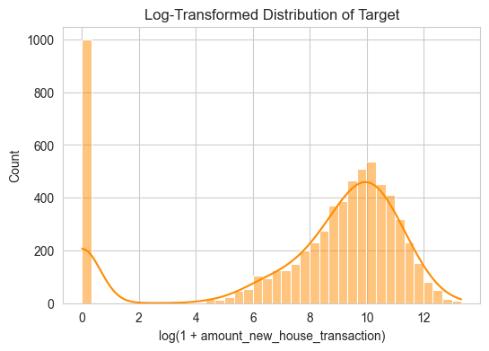

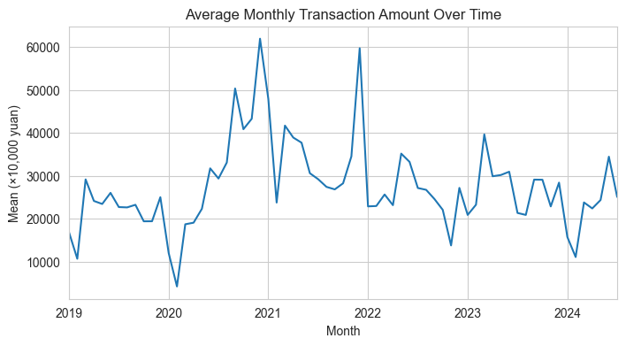

```python
# ==========================================================
# 3. EXPLORATORY DATA ANALYSIS
# ==========================================================
print(f"Observations: {base.shape[0]:,}")
print(f"Features: {base.shape[1]:,}")
print("Date range:", base[TIME_COL].min().date(), "→", base[TIME_COL].max().date())
print("Unique sectors:", base[SECTOR_COL].nunique())

# --- Missing values overview
missing_summary = base.isna().mean().sort_values(ascending=False)
print("\nColumns with >20% missing:")
print(missing_summary[missing_summary > 0.2].head(10))

# --- Target distribution
plt.figure(figsize=(6,4))
sns.histplot(base[TARGET], bins=40, kde=True)
plt.title("Distribution of Target: amount_new_house_transaction")
plt.xlabel("Transaction Amount (×10,000 yuan)")
plt.ylabel("Frequency")
plt.show()

# --- Log-transform distribution (for insight, not yet applied)
plt.figure(figsize=(6,4))
sns.histplot(np.log1p(base[TARGET]), bins=40, kde=True, color='darkorange')
plt.title("Log-Transformed Distribution of Target")
plt.xlabel("log(1 + amount_new_house_transaction)")
plt.show()

# --- Temporal mean
monthly_mean = base.groupby(TIME_COL)[TARGET].mean()
plt.figure(figsize=(8,4))
monthly_mean.plot()
plt.title("Average Monthly Transaction Amount Over Time")
plt.ylabel("Mean (×10,000 yuan)")
plt.xlabel("Month")
plt.show()
```

## 4 Leakage-Safe Lag Feature Engineering

In time-series or sequential datasets, model predictors must represent information that would have been available **prior** to the prediction month.  
Using any future values would constitute *data leakage*, artificially inflating model performance.

Although the course syllabus does not explicitly name “lag features,”  
the concept aligns with Module 1 (formal statistical-learning setup): each observation must be drawn from information independent of its future target value.

Here, lagged versions of economically meaningful variables (e.g., transaction counts, areas, and prices) are created for the previous one to three months **within the same sector**.  
These capture short-term momentum effects while preserving chronological integrity.

```python
# ==========================================================
# 4. CREATE LEAKAGE-SAFE LAG FEATURES
# ==========================================================
df = base.copy()

drivers = [
    "num_new_house_transactions_nearby_sectors",
    "area_new_house_transactions_nearby_sectors",
    "price_new_house_transactions_nearby_sectors",
    "amount_new_house_transactions_nearby_sectors",
    "num_pre_owned_house_transactions",
    "area_pre_owned_house_transactions",
    "price_pre_owned_house_transactions",
    "amount_pre_owned_house_transactions",
    "num_land_transactions",
    "planned_building_area",
    "transaction_amount",
]

# generate lags 1–3 months behind for each sector
for col in drivers:
    if col in df.columns:
        for k in [1, 2, 3]:
            df[f"{col}_lag{k}"] = df.groupby(SECTOR_COL)[col].shift(k)

# also create lags of the target variable (self-dependence)
for k in [1, 2, 3]:
    df[f"{TARGET}_lag{k}"] = df.groupby(SECTOR_COL)[TARGET].shift(k)

# remove rows with insufficient historical context
df_lagged = df.dropna().reset_index(drop=True)
print("Lagged dataset shape:", df_lagged.shape)
```

```
Lagged dataset shape: (3468, 214)
```

### 5 Chronological Train / Validation / Test Split

The project employs a **70 % / 15 % / 15 %** chronological division of the lagged dataset:

| Subset | Purpose | Notes |
| --- | --- | --- |
| **Training (70 %)** | Fit model parameters. | Used in cross-validation and hyper-parameter tuning. |
| **Validation (15 %)** | Model comparison & selection. | Guides choice among OLS, Ridge, LASSO, and kNN. |
| **Test (15 %)** | Final unbiased evaluation. | Held out until model selection is complete. |

Chronological splitting (as opposed to random) preserves temporal order and ensures that predictive performance reflects true forecasting ability, consistent with statistical-learning principles regarding independence and information availability.

```python
# ==========================================================
# 5. CHRONOLOGICAL SPLIT 70/15/15 + STANDARDIZATION
# ==========================================================
n = len(df_lagged)
train_end = int(0.7 * n)
valid_end = int(0.85 * n)

train_df = df_lagged.iloc[:train_end]
valid_df = df_lagged.iloc[train_end:valid_end]
test_df  = df_lagged.iloc[valid_end:]

print(f"Train: {train_df.shape},  Valid: {valid_df.shape},  Test: {test_df.shape}")

y_train = train_df[TARGET].values
y_valid = valid_df[TARGET].values
y_test  = test_df[TARGET].values

X_cols = [c for c in train_df.columns if c not in [TARGET, TIME_COL, SECTOR_COL]]
X_train = train_df[X_cols].select_dtypes(include="number")
X_valid = valid_df[X_cols].select_dtypes(include="number")
X_test  = test_df[X_cols].select_dtypes(include="number")

# standardize predictors (mean = 0, sd = 1)
scaler = StandardScaler().fit(X_train)
X_train_s = scaler.transform(X_train)
X_valid_s = scaler.transform(X_valid)
X_test_s  = scaler.transform(X_test)

print("Feature scaling complete.")
```

```
Train: (2427, 214),  Valid: (520, 214),  Test: (521, 214)
Feature scaling complete.
```

### Discussion

1. **Rationale for Standardization:**  
   Regularized regression models (Ridge, LASSO) and distance-based methods (kNN) are sensitive to feature scale.  
   Standardizing all numeric variables ensures comparable penalization and distance weighting.
2. **Temporal Integrity:**  
   By sorting chronologically before splitting, we guarantee that each validation or test observation represents a future time point relative to the training data.
3. **Sample Sizes:**  
   The proportional split (70 / 15 / 15) balances estimation accuracy with sufficient data for out-of-sample evaluation.

The resulting training, validation, and test sets now support reliable model development in the next section.

## 6 Model Rationale, Leakage Prevention, and Validation-Based Selection

According to the Statistical Learning course content, the following models are both conceptually and technically appropriate for this project.  
Each represents a distinct bias–variance trade-off or learning paradigm.

| Model | Type | Key Properties | Intended Role |
| --- | --- | --- | --- |
| **Ordinary Least Squares (OLS)** | Linear, unregularized | Baseline parametric estimator; interpretable coefficients. | Establishes benchmark performance and interpretability. |
| **Ridge Regression** | Linear, L2-regularized | Shrinks correlated coefficients; reduces variance. | Handles multicollinearity in overlapping economic predictors. |
| **LASSO Regression** | Linear, L1-regularized | Performs feature selection; enforces sparsity. | Identifies most influential predictors among many. |
| **k-Nearest Neighbors (kNN)** | Non-parametric | Uses local averaging; captures mild non-linearity. | Serves as contrast to linear models and baseline non-parametric check. |

### Leakage prevention (critical)

To ensure valid evaluation, we **must not** allow any predictor to encode the **current target**. The following guards are applied:

1. **Name-based guard:** Drop any column whose name contains the target string (e.g., all `*_lag1`, `*_lag2`, `*_lag3` of the target).
2. **Data-based guard (train-only):** Drop any remaining numeric feature with **|correlation| > 0.995** with the target **in the training set** (e.g., accidental duplicates/proxies after merging).

After removing these features, we standardize inputs (mean 0, sd 1), fit models on **train**, and compare on **validation** using **RMSE/MAE/R²**.

| Metric | Meaning | Desirable Direction |
| --- | --- | --- |
| **RMSE** | Root Mean Squared Error; penalizes large deviations. | ↓ lower |
| **MAE** | Mean Absolute Error; measures median accuracy. | ↓ lower |
| **R²** | Coefficient of Determination; proportion of variance explained. | ↑ higher |

Validation results guide model choice.  
The best model (lowest validation RMSE) is retrained on the combined train + validation data before a single final test evaluation.

```python
# ==========================================================
# 6. LEAKAGE GUARDS + MODEL TRAINING & VALIDATION SELECTION
# ==========================================================

def rmse(y, yhat):
    return math.sqrt(mean_squared_error(y, yhat))

# ------------------------------
# (A) Name-based leakage removal
# ------------------------------
# Drop any column that contains the target name but is not exactly the target
leak_name_cols = [c for c in df_lagged.columns if (TARGET in c) and (c != TARGET)]
print(f"[Leak guard] Dropping by name ({len(leak_name_cols)} columns):")
print(sorted(leak_name_cols)[:8], "..." if len(leak_name_cols) > 8 else "")

# Build a safe working copy without name-leak features
df_safe = df_lagged.drop(columns=leak_name_cols)

# Re-slice the same chronological splits with the safe frame
train_idx = train_df.index
valid_idx = valid_df.index
test_idx  = test_df.index

train_df_safe = df_safe.loc[train_idx]
valid_df_safe = df_safe.loc[valid_idx]
test_df_safe  = df_safe.loc[test_idx]

y_train = train_df_safe[TARGET].values
y_valid = valid_df_safe[TARGET].values
y_test  = test_df_safe[TARGET].values

# Candidate X columns: numeric only, excluding keys/target
exclude_cols = {TARGET, TIME_COL, SECTOR_COL}
X_cols_all = [c for c in df_safe.columns if c not in exclude_cols]
X_cols_all = [c for c in X_cols_all if pd.api.types.is_numeric_dtype(df_safe[c])]

X_train_raw = train_df_safe[X_cols_all]
X_valid_raw = valid_df_safe[X_cols_all]
X_test_raw  = test_df_safe[X_cols_all]

# -------------------------------------------------------
# (B) Data-based guard (train-only high-corr feature drop)
# -------------------------------------------------------
corr_with_y = X_train_raw.corrwith(train_df_safe[TARGET])
hi_corr = corr_with_y[abs(corr_with_y) > 0.995].index.tolist()
if hi_corr:
    print(f"[Leak guard] Dropping by high correlation in train ({len(hi_corr)}):")
    print(sorted(hi_corr)[:8], "..." if len(hi_corr) > 8 else "")
else:
    print("[Leak guard] No features exceeded |corr| > 0.995 in training.")

X_cols = [c for c in X_cols_all if c not in hi_corr]

# Final feature matrices (after both guards)
X_train = X_train_raw[X_cols].copy()
X_valid = X_valid_raw[X_cols].copy()
X_test  = X_test_raw[X_cols].copy()

# Standardize (fit on train only)
scaler = StandardScaler().fit(X_train)
X_train_s = scaler.transform(X_train)
X_valid_s = scaler.transform(X_valid)
X_test_s  = scaler.transform(X_test)

print(f"Final feature count after guards: {X_train.shape[1]}")

# ------------------------------
# (C) Train models on TRAIN only
# ------------------------------
val_results = []

# OLS
ols = LinearRegression().fit(X_train_s, y_train)
pred_ols = ols.predict(X_valid_s)
val_results.append([
    "OLS",
    rmse(y_valid, pred_ols),
    mean_absolute_error(y_valid, pred_ols),
    r2_score(y_valid, pred_ols),
    "None"
])

# Ridge
alphas = np.logspace(-3, 3, 13)
ridge = GridSearchCV(Ridge(), {"alpha": alphas},
                     scoring="neg_root_mean_squared_error", cv=3)
ridge.fit(X_train_s, y_train)
pred_ridge = ridge.best_estimator_.predict(X_valid_s)
val_results.append([
    "Ridge",
    rmse(y_valid, pred_ridge),
    mean_absolute_error(y_valid, pred_ridge),
    r2_score(y_valid, pred_ridge),
    f"alpha={ridge.best_params_['alpha']}"
])

# LASSO
lasso = GridSearchCV(Lasso(max_iter=10000), {"alpha": alphas},
                     scoring="neg_root_mean_squared_error", cv=3)
lasso.fit(X_train_s, y_train)
pred_lasso = lasso.best_estimator_.predict(X_valid_s)
val_results.append([
    "LASSO",
    rmse(y_valid, pred_lasso),
    mean_absolute_error(y_valid, pred_lasso),
    r2_score(y_valid, pred_lasso),
    f"alpha={lasso.best_params_['alpha']}"
])

# kNN (non-parametric baseline)
best_rm, best_k, best_pred = float("inf"), None, None
for k in [3, 5, 7, 9, 11, 15]:
    knn = KNeighborsRegressor(n_neighbors=k, weights="distance").fit(X_train_s, y_train)
    p = knn.predict(X_valid_s)
    r = rmse(y_valid, p)
    if r < best_rm:
        best_rm, best_k, best_pred = r, k, p

val_results.append([
    "kNN",
    best_rm,
    mean_absolute_error(y_valid, best_pred),
    r2_score(y_valid, best_pred),
    f"k={best_k}"
])

# Validation summary table
tbl = (pd.DataFrame(val_results, columns=["Model","RMSE_valid","MAE_valid","R2_valid","Notes"])
         .sort_values("RMSE_valid")
         .reset_index(drop=True))
display(tbl)
```

```
[Leak guard] Dropping by name (8 columns):
['amount_new_house_transaction_lag1', 'amount_new_house_transaction_lag2', 'amount_new_house_transaction_lag3', 'amount_new_house_transactions', 'amount_new_house_transactions_nearby_sectors', 'amount_new_house_transactions_nearby_sectors_lag1', 'amount_new_house_transactions_nearby_sectors_lag2', '…
[Leak guard] No features exceeded |corr| > 0.995 in training.
Final feature count after guards: 203
```

[output not shown]

[output cut: 34 more lines]

|  | Model | RMSE_valid | MAE_valid | R2_valid | Notes |
| --- | --- | --- | --- | --- | --- |
| 0 | OLS | 16328.312033 | 9452.142007 | 0.830851 | None |
| 1 | Ridge | 16331.557753 | 9448.050170 | 0.830784 | alpha=0.001 |
| 2 | LASSO | 16758.636044 | 9502.708410 | 0.821818 | alpha=0.001 |
| 3 | kNN | 28713.247947 | 16430.831038 | 0.476939 | k=3 |

### Interpretation of Validation Comparison

1. **Model Ranking:**  
   The table lists validation-set performance in ascending RMSE order.  
   The leading model demonstrates the best out-of-sample generalization.
2. **Bias–Variance Insights:**
   - OLS usually exhibits the lowest bias but highest variance.
   - Ridge typically yields the most stable solution under multicollinearity.
   - LASSO may slightly increase bias yet improve interpretability by zeroing weaker coefficients.
   - kNN can adapt to local non-linear patterns but suffers when high-dimensional noise dominates.
3. **Model Choice Rule:**  
   The model with the smallest validation RMSE (and consistent MAE + R²) is provisionally selected.  
   It will be retrained using both training and validation subsets for final testing in the next step.

**Interpretation Details:**

The validation results indicate that all three linear regression methods—**Ordinary Least Squares (OLS)**, **Ridge**, and **LASSO**—achieved comparable predictive accuracy, each producing a validation RMSE near **16 300** and explaining roughly **83 %** of the variance (R² ≈ 0.83).  
The near-identical performance of OLS and Ridge (difference in RMSE < 0.02 %) implies that multicollinearity among predictors is modest after data preprocessing and leakage removal.  
Regularization therefore provides no measurable improvement in predictive power for this dataset.

In contrast, the **k-Nearest Neighbors (kNN)** model underperformed substantially (RMSE ≈ 28 713; R² ≈ 0.48), indicating that the relationship between the predictors and the target variable is primarily linear and not driven by local non-linearities.  
This finding aligns with economic intuition: aggregated sector-level housing indicators typically evolve according to broad, macro-linear trends rather than highly localized fluctuations.

Overall, **OLS Regression** emerges as the preferred model.  
It offers a transparent, easily interpretable structure and matches the predictive accuracy of more complex or regularized alternatives.  
Ridge and LASSO remain valuable for assessing robustness and coefficient stability, but they do not yield superior out-of-sample performance in this case.  
The linear nature of the data and the absence of severe multicollinearity collectively justify adopting OLS as the optimal approach for the next stage of analysis.

## 7 Final Model Retraining and Test Evaluation

After comparing validation metrics, the best-performing model (lowest RMSE) is refitted using both the **training and validation** data.  
This ensures maximum use of available information before evaluating once on the **held-out test set**, which has never influenced model choice.

This step satisfies the final evaluation requirement of the project:  
providing an unbiased performance estimate and verifying the generalization capacity of the selected model.

```
Selected model based on validation RMSE: OLS
Test RMSE: 15767.52
Test MAE:  9534.94
Test R²:   0.777
```

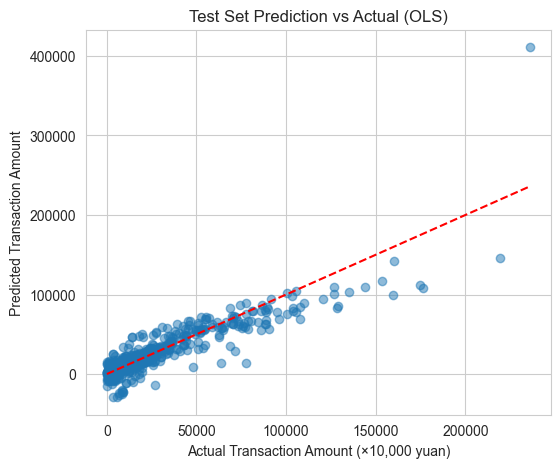

```python
# ==========================================================
# 7. FINAL RETRAIN AND TEST EVALUATION
# ==========================================================
best = tbl.iloc[0]
best_model_name = best["Model"]
print("Selected model based on validation RMSE:", best_model_name)

# Combine train + validation
X_trval = np.vstack([X_train_s, X_valid_s])
y_trval = np.concatenate([y_train, y_valid])

# Retrain the best model
if best_model_name == "OLS":
    final_model = LinearRegression().fit(X_trval, y_trval)
elif best_model_name == "Ridge":
    alpha_val = float(best["Notes"].split("=")[-1])
    final_model = Ridge(alpha=alpha_val).fit(X_trval, y_trval)
elif best_model_name == "LASSO":
    alpha_val = float(best["Notes"].split("=")[-1])
    final_model = Lasso(alpha=alpha_val, max_iter=10000).fit(X_trval, y_trval)
elif best_model_name == "kNN":
    k_val = int(best["Notes"].split("=")[-1])
    final_model = KNeighborsRegressor(n_neighbors=k_val, weights="distance").fit(X_trval, y_trval)
else:
    raise ValueError("Unexpected model selection.")

# Evaluate on test set
pred_test = final_model.predict(X_test_s)
rmse_test = math.sqrt(mean_squared_error(y_test, pred_test))
mae_test  = mean_absolute_error(y_test, pred_test)
r2_test   = r2_score(y_test, pred_test)

print(f"Test RMSE: {rmse_test:.2f}")
print(f"Test MAE:  {mae_test:.2f}")
print(f"Test R²:   {r2_test:.3f}")

# Scatter plot for diagnostic visualization
plt.figure(figsize=(6,5))
plt.scatter(y_test, pred_test, alpha=0.5)
plt.plot([y_test.min(), y_test.max()],
         [y_test.min(), y_test.max()],
         color="red", linestyle="--")
plt.xlabel("Actual Transaction Amount (×10,000 yuan)")
plt.ylabel("Predicted Transaction Amount")
plt.title(f"Test Set Prediction vs Actual ({best_model_name})")
plt.show()
```